# Data Analysis Project :Titanic DataSet

### By Gokula Chandra.K ((21.05.2021))

In this worksheet , we will analyse the famous dataset on kaggle  
And also on survival chances of passengers on multiple factors  
we will answer the following questions  
Who were the passengers on the Titanic? (based on categories like age, gender, class.. etc)  
What deck were the passengers on and how does that relate to their class?  
Where did the passengers come from?(City)  
What is the relation between survival chance and passenger travelling status?(Alone or with Family)  
What are the factors affected a passenger in the process of survival in the disaster?  
Importing the required packages..........

The dataset related to titanic information is downloaded from kaggle  
Reading the dataset using read_csv()

```python
import pandas as pd
import seaborn as sns
import matplotlib.pyplot as plt
train=pd.read_csv('train.csv')
titanic_df = pd.read_csv('tested.csv')
```

```python
titanic_df.head()
```

|  | PassengerId | Survived | Pclass | Name | Sex | Age | SibSp | Parch | Ticket | Fare | Cabin | Embarked |
| --- | --- | --- | --- | --- | --- | --- | --- | --- | --- | --- | --- | --- |
| 0 | 892 | 0 | 3 | Kelly, Mr. James | male | 34.5 | 0 | 0 | 330911 | 7.8292 | NaN | Q |
| 1 | 893 | 1 | 3 | Wilkes, Mrs. James (Ellen Needs) | female | 47.0 | 1 | 0 | 363272 | 7.0000 | NaN | S |
| 2 | 894 | 0 | 2 | Myles, Mr. Thomas Francis | male | 62.0 | 0 | 0 | 240276 | 9.6875 | NaN | Q |
| 3 | 895 | 0 | 3 | Wirz, Mr. Albert | male | 27.0 | 0 | 0 | 315154 | 8.6625 | NaN | S |
| 4 | 896 | 1 | 3 | Hirvonen, Mrs. Alexander (Helga E Lindqvist) | female | 22.0 | 1 | 1 | 3101298 | 12.2875 | NaN | S |

An Complete info regarding the entries in the dataset along with the data types including their count  
Other attributes of intervals at 25,50,75 and max along with standard dev. of those values (Complete description)

```python
titanic_df.info()
```

```
<class 'pandas.core.frame.DataFrame'>
RangeIndex: 418 entries, 0 to 417
Data columns (total 12 columns):
 #   Column       Non-Null Count  Dtype
---  ------       --------------  -----
 0   PassengerId  418 non-null    int64
 1   Survived     418 non-null    int64
 2   Pclass       418 non-null    int64
 3   Name         418 non-null    object
 4   Sex          418 non-null    object
 5   Age          332 non-null    float64
 6   SibSp        418 non-null    int64
 7   Parch        418 non-null    int64
 8   Ticket       418 non-null    object
 9   Fare         417 non-null    float64
 10  Cabin        91 non-null     object
 11  Embarked     418 non-null    object
dtypes: float64(2), int64(5), object(5)
memory usage: 39.3+ KB
```

```python
titanic_df.describe(include='all')
```

|  | PassengerId | Survived | Pclass | Name | Sex | Age | SibSp | Parch | Ticket | Fare | Cabin | Embarked |
| --- | --- | --- | --- | --- | --- | --- | --- | --- | --- | --- | --- | --- |
| count | 418.000000 | 418.000000 | 418.000000 | 418 | 418 | 332.000000 | 418.000000 | 418.000000 | 418 | 417.000000 | 91 | 418 |
| unique | NaN | NaN | NaN | 418 | 2 | NaN | NaN | NaN | 363 | NaN | 76 | 3 |
| top | NaN | NaN | NaN | Weisz, Mr. Leopold | male | NaN | NaN | NaN | PC 17608 | NaN | B57 B59 B63 B66 | S |
| freq | NaN | NaN | NaN | 1 | 266 | NaN | NaN | NaN | 5 | NaN | 3 | 270 |
| mean | 1100.500000 | 0.363636 | 2.265550 | NaN | NaN | 30.272590 | 0.447368 | 0.392344 | NaN | 35.627188 | NaN | NaN |
| std | 120.810458 | 0.481622 | 0.841838 | NaN | NaN | 14.181209 | 0.896760 | 0.981429 | NaN | 55.907576 | NaN | NaN |
| min | 892.000000 | 0.000000 | 1.000000 | NaN | NaN | 0.170000 | 0.000000 | 0.000000 | NaN | 0.000000 | NaN | NaN |
| 25% | 996.250000 | 0.000000 | 1.000000 | NaN | NaN | 21.000000 | 0.000000 | 0.000000 | NaN | 7.895800 | NaN | NaN |
| 50% | 1100.500000 | 0.000000 | 3.000000 | NaN | NaN | 27.000000 | 0.000000 | 0.000000 | NaN | 14.454200 | NaN | NaN |
| 75% | 1204.750000 | 1.000000 | 3.000000 | NaN | NaN | 39.000000 | 1.000000 | 0.000000 | NaN | 31.500000 | NaN | NaN |
| max | 1309.000000 | 1.000000 | 3.000000 | NaN | NaN | 76.000000 | 8.000000 | 9.000000 | NaN | 512.329200 | NaN | NaN |

**There are various plots in seaborn module one of such is factor plot but it is updated in present versions hence**  
**we use catplot in its place to visualize the dataframe in form of a graph with axes metrics**

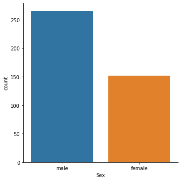

```python
sns.factorplot('Sex',data=titanic_df,kind='count')
```

**Visual representation of passengers based on Gender parameters**

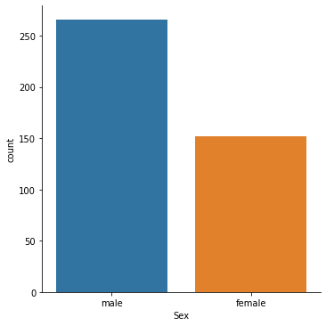

```python
sns.catplot(x='Sex',kind='count',data=titanic_df)
```

Ostentatiously , we see male count is more than female count as per above graph  
Lets visualize on basis of Pclass attribute to have an unvague view:

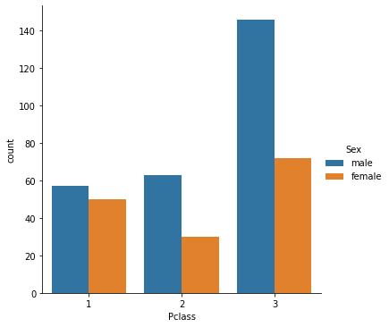

```python
sns.catplot(x='Pclass',data=titanic_df,hue='Sex',kind='count')
```

Now, we try adding a column named Person in the titanic data frame by checking it with the condition as with age and also we use apply method to do so,  
WE Classify them as Child if there age falls below 16 else remain unchanged

```python
def mwc(passenger):
    age=passenger['Age']
    sex=passenger['Sex']
    return 'child' if age<16 else sex
titanic_df['Person'] = titanic_df.apply(mwc,axis=1)
```

```python
titanic_df[0:100]
```

|  | PassengerId | Survived | Pclass | Name | Sex | Age | SibSp | Parch | Ticket | Fare | Cabin | Embarked | Person |
| --- | --- | --- | --- | --- | --- | --- | --- | --- | --- | --- | --- | --- | --- |
| 0 | 892 | 0 | 3 | Kelly, Mr. James | male | 34.5 | 0 | 0 | 330911 | 7.8292 | NaN | Q | male |
| 1 | 893 | 1 | 3 | Wilkes, Mrs. James (Ellen Needs) | female | 47.0 | 1 | 0 | 363272 | 7.0000 | NaN | S | female |
| 2 | 894 | 0 | 2 | Myles, Mr. Thomas Francis | male | 62.0 | 0 | 0 | 240276 | 9.6875 | NaN | Q | male |
| 3 | 895 | 0 | 3 | Wirz, Mr. Albert | male | 27.0 | 0 | 0 | 315154 | 8.6625 | NaN | S | male |
| 4 | 896 | 1 | 3 | Hirvonen, Mrs. Alexander (Helga E Lindqvist) | female | 22.0 | 1 | 1 | 3101298 | 12.2875 | NaN | S | female |
| ... | ... | ... | ... | ... | ... | ... | ... | ... | ... | ... | ... | ... | ... |
| 95 | 987 | 0 | 3 | Tenglin, Mr. Gunnar Isidor | male | 25.0 | 0 | 0 | 350033 | 7.7958 | NaN | S | male |
| 96 | 988 | 1 | 1 | Cavendish, Mrs. Tyrell William (Julia Florence... | female | 76.0 | 1 | 0 | 19877 | 78.8500 | C46 | S | female |
| 97 | 989 | 0 | 3 | Makinen, Mr. Kalle Edvard | male | 29.0 | 0 | 0 | STON/O 2. 3101268 | 7.9250 | NaN | S | male |
| 98 | 990 | 1 | 3 | Braf, Miss. Elin Ester Maria | female | 20.0 | 0 | 0 | 347471 | 7.8542 | NaN | S | female |
| 99 | 991 | 0 | 3 | Nancarrow, Mr. William Henry | male | 33.0 | 0 | 0 | A./5. 3338 | 8.0500 | NaN | S | male |

100 rows × 13 columns

**Now, we see survival chances among the Person class (Distribution chart)**

```python
p_sur=titanic_df.groupby(['Person','Survived'])
p_sur.describe()
```

| Person | Survived | PassengerId count | PassengerId mean | PassengerId std | PassengerId min | PassengerId 25% | PassengerId 50% | PassengerId 75% | PassengerId max | Pclass count | Pclass mean | ... | Parch 75% | Parch max | Fare count | Fare mean | Fare std | Fare min | Fare 25% | Fare 50% | Fare 75% | Fare max |
| --- | --- | --- | --- | --- | --- | --- | --- | --- | --- | --- | --- | --- | --- | --- | --- | --- | --- | --- | --- | --- | --- | --- |
| child | 0 | 19.0 | 1089.368421 | 126.725079 | 897.0 | 976.5 | 1086.0 | 1186.0 | 1284.0 | 19.0 | 2.631579 | ... | 2.0 | 2.0 | 19.0 | 42.898021 | 61.256029 | 3.1708 | 14.45000 | 21.075 | 31.94375 | 262.3750 |
|  | 1 | 13.0 | 1139.692308 | 91.677319 | 1009.0 | 1067.0 | 1155.0 | 1188.0 | 1301.0 | 13.0 | 2.538462 | ... | 2.0 | 2.0 | 13.0 | 25.743908 | 12.007686 | 12.1833 | 15.75000 | 20.575 | 39.00000 | 46.9000 |
| female | 1 | 139.0 | 1092.776978 | 125.406819 | 893.0 | 981.0 | 1089.0 | 1205.5 | 1306.0 | 139.0 | 2.107914 | ... | 1.0 | 9.0 | 139.0 | 51.992658 | 76.003262 | 6.9500 | 8.05000 | 22.025 | 59.40000 | 512.3292 |
| male | 0 | 247.0 | 1103.639676 | 119.158720 | 892.0 | 1000.5 | 1109.0 | 1206.0 | 1309.0 | 247.0 | 2.311741 | ... | 0.0 | 9.0 | 246.0 | 26.340752 | 39.025284 | 0.0000 | 7.85105 | 11.925 | 26.00000 | 262.3750 |

4 rows × 48 columns

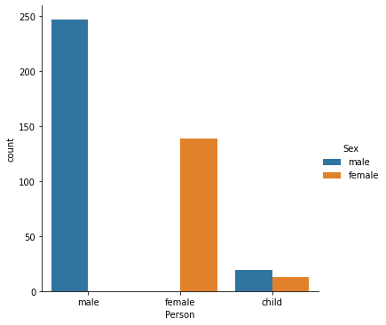

```python
sns.catplot(x='Person',data=titanic_df,hue='Sex',kind='count')
```

**Lets have an count of all categories of persons along their respective counts**  
**And also lets have a survival distribution between male and female**

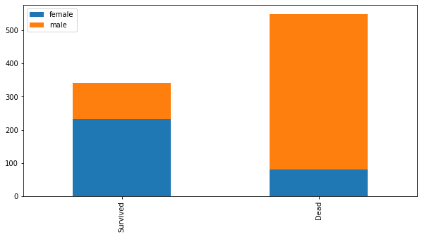

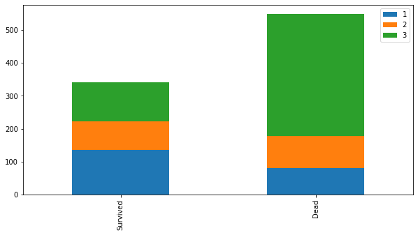

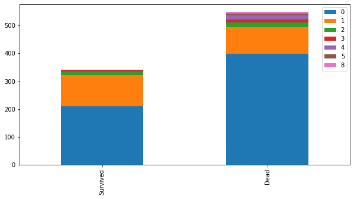

```python
def bar_plot(feature):
    survive = train[train['Survived']==1][feature].value_counts()
    dead    = train[train['Survived']==0][feature].value_counts()
    tf=pd.DataFrame([survive,dead])
    tf.index=['Survived','Dead']
    tf.plot(kind='bar',stacked=True,figsize=(10,5))
bar_plot('Sex')
bar_plot('Pclass')
bar_plot('SibSp')
```

```python
print(titanic_df['Person'].value_counts())
```

```
male      247
female    139
child      32
Name: Person, dtype: int64
```

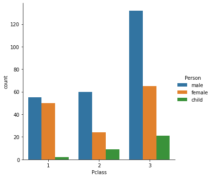

```python
sns.catplot(x='Pclass',data=titanic_df,hue='Person',kind='count')
```

**Histogram of ages will give more general perspective on the ages of the persons..**

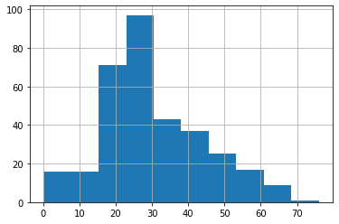

```python
titanic_df['Age'].hist()
```

Now, we have FacetGrid from seaborn module which facilitate us to have wider view of distributions along with  
regions under the curve as shaded and also kdeplot will let us know local minima and maxima of the distribution  
here, we plot them against the Pclass and Sex parameters

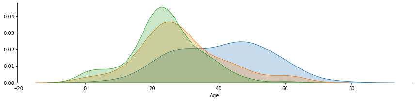

```python
fig = sns.FacetGrid(titanic_df,hue='Pclass',aspect=4)
fig.map(sns.kdeplot,'Age',shade=True)
#fig.map(sns.scatterplot,"Age","Person")
```

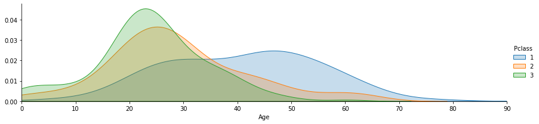

```python
fig = sns.FacetGrid(titanic_df,hue='Pclass',aspect=4)
fig.map(sns.kdeplot,'Age',shade=True)
fig.set(xlim=(0,90))
fig.add_legend()
```

We have certain range of palette to better locate the components of the curve along with continous probability  
density curve as analagous to histogram

```python
sns.color_palette("Set3")
```

```python
sns.color_palette("Set2")
```

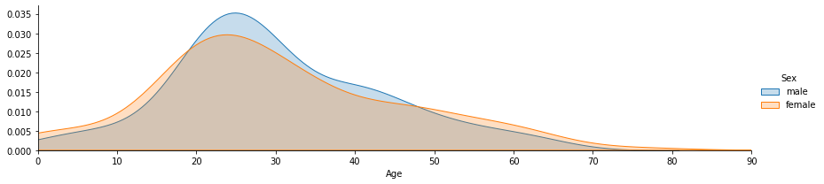

```python
sns.color_palette("Set2")
fig = sns.FacetGrid(titanic_df,hue='Sex',aspect=4)
fig.map(sns.kdeplot,'Age',shade=True)
fig.set(xlim=(0,90))
fig.add_legend()
```

**flare**

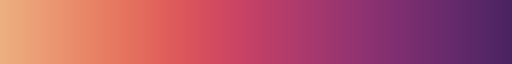

```python
sns.color_palette("flare",as_cmap=True)
```

## Now,we are trying to find the distribution and Analysis of passengers based on Decks

```python
deck_df = titanic_df.dropna(axis=0)
deck_df.head()
```

|  | PassengerId | Survived | Pclass | Name | Sex | Age | SibSp | Parch | Ticket | Fare | Cabin | Embarked | Person |
| --- | --- | --- | --- | --- | --- | --- | --- | --- | --- | --- | --- | --- | --- |
| 12 | 904 | 1 | 1 | Snyder, Mrs. John Pillsbury (Nelle Stevenson) | female | 23.0 | 1 | 0 | 21228 | 82.2667 | B45 | S | female |
| 14 | 906 | 1 | 1 | Chaffee, Mrs. Herbert Fuller (Carrie Constance... | female | 47.0 | 1 | 0 | W.E.P. 5734 | 61.1750 | E31 | S | female |
| 24 | 916 | 1 | 1 | Ryerson, Mrs. Arthur Larned (Emily Maria Borie) | female | 48.0 | 1 | 3 | PC 17608 | 262.3750 | B57 B59 B63 B66 | C | female |
| 26 | 918 | 1 | 1 | Ostby, Miss. Helene Ragnhild | female | 22.0 | 0 | 1 | 113509 | 61.9792 | B36 | C | female |
| 28 | 920 | 0 | 1 | Brady, Mr. John Bertram | male | 41.0 | 0 | 0 | 113054 | 30.5000 | A21 | S | male |

```python
deck_df.info()
```

```
<class 'pandas.core.frame.DataFrame'>
Int64Index: 87 entries, 12 to 414
Data columns (total 13 columns):
 #   Column       Non-Null Count  Dtype
---  ------       --------------  -----
 0   PassengerId  87 non-null     int64
 1   Survived     87 non-null     int64
 2   Pclass       87 non-null     int64
 3   Name         87 non-null     object
 4   Sex          87 non-null     object
 5   Age          87 non-null     float64
 6   SibSp        87 non-null     int64
 7   Parch        87 non-null     int64
 8   Ticket       87 non-null     object
 9   Fare         87 non-null     float64
 10  Cabin        87 non-null     object
 11  Embarked     87 non-null     object
 12  Person       87 non-null     object
dtypes: float64(2), int64(5), object(6)
memory usage: 9.5+ KB
```

**Here, we classify based on decks:**

```python
def get_level(passenger):
    cabin = passenger['Cabin']
    return cabin[0]
deck_df['level']=deck_df.apply(get_level,axis=1)
```

```python
deck_df.head()
```

|  | PassengerId | Survived | Pclass | Name | Sex | Age | SibSp | Parch | Ticket | Fare | Cabin | Embarked | Person | level |
| --- | --- | --- | --- | --- | --- | --- | --- | --- | --- | --- | --- | --- | --- | --- |
| 12 | 904 | 1 | 1 | Snyder, Mrs. John Pillsbury (Nelle Stevenson) | female | 23.0 | 1 | 0 | 21228 | 82.2667 | B45 | S | female | B |
| 14 | 906 | 1 | 1 | Chaffee, Mrs. Herbert Fuller (Carrie Constance... | female | 47.0 | 1 | 0 | W.E.P. 5734 | 61.1750 | E31 | S | female | E |
| 24 | 916 | 1 | 1 | Ryerson, Mrs. Arthur Larned (Emily Maria Borie) | female | 48.0 | 1 | 3 | PC 17608 | 262.3750 | B57 B59 B63 B66 | C | female | B |
| 26 | 918 | 1 | 1 | Ostby, Miss. Helene Ragnhild | female | 22.0 | 0 | 1 | 113509 | 61.9792 | B36 | C | female | B |
| 28 | 920 | 0 | 1 | Brady, Mr. John Bertram | male | 41.0 | 0 | 0 | 113054 | 30.5000 | A21 | S | male | A |

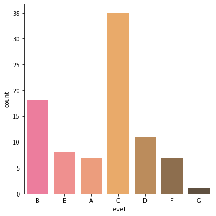

```python
sns.catplot(x='level',data=deck_df,palette='spring_d',kind='count')
```

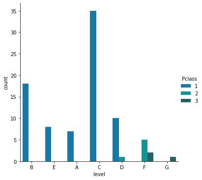

```python
sns.catplot(x='level',data=deck_df,palette='winter_d',hue='Pclass',kind='count')
```

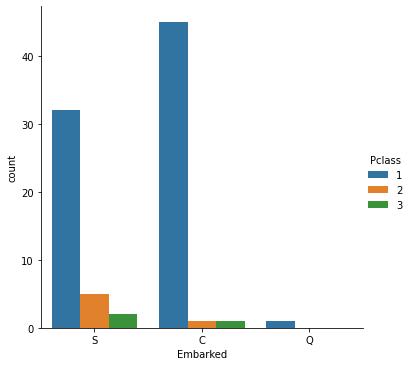

```python
sns.catplot(x='Embarked',data=deck_df,hue='Pclass',kind='count')
```

## We notice that Decks(A,B,C,D,E) related to class 1 and Decks(D,F) related to class 2 and Decks(F,G) related to class3

We will find the distribution of passengers based on the embarked cities  
S=Southampton  
Q=Queenstown  
c=Cherbourg

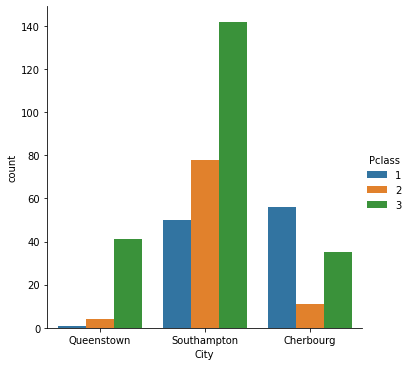

```python
def getcity(passe):
    em=passe['Embarked']
    if em=='Q':
        return 'Queenstown'
    if em=='S':
        return 'Southampton'
    return 'Cherbourg'
titanic_df['City']=titanic_df.apply(getcity,axis=1)
sns.catplot(data=titanic_df,kind='count',x='City',hue='Pclass')
```

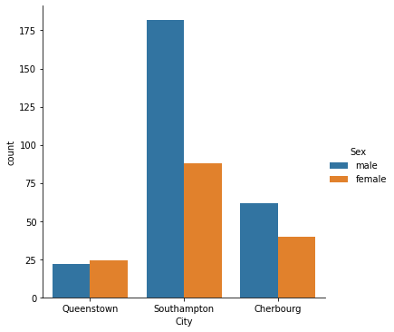

```python
sns.catplot(data=titanic_df,x="City",hue="Sex",kind='count')
```

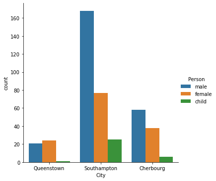

```python
sns.catplot(data=titanic_df,x='City',hue='Person',kind='count')
```

**We observe that from Southampton city passengers turned up to be more**

```python
titanic_df.head()
```

|  | PassengerId | Survived | Pclass | Name | Sex | Age | SibSp | Parch | Ticket | Fare | Cabin | Embarked | Person | City |
| --- | --- | --- | --- | --- | --- | --- | --- | --- | --- | --- | --- | --- | --- | --- |
| 0 | 892 | 0 | 3 | Kelly, Mr. James | male | 34.5 | 0 | 0 | 330911 | 7.8292 | NaN | Q | male | Queenstown |
| 1 | 893 | 1 | 3 | Wilkes, Mrs. James (Ellen Needs) | female | 47.0 | 1 | 0 | 363272 | 7.0000 | NaN | S | female | Southampton |
| 2 | 894 | 0 | 2 | Myles, Mr. Thomas Francis | male | 62.0 | 0 | 0 | 240276 | 9.6875 | NaN | Q | male | Queenstown |
| 3 | 895 | 0 | 3 | Wirz, Mr. Albert | male | 27.0 | 0 | 0 | 315154 | 8.6625 | NaN | S | male | Southampton |
| 4 | 896 | 1 | 3 | Hirvonen, Mrs. Alexander (Helga E Lindqvist) | female | 22.0 | 1 | 1 | 3101298 | 12.2875 | NaN | S | female | Southampton |

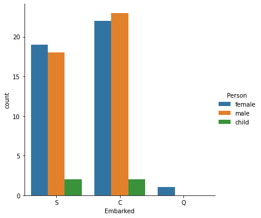

```python
sns.catplot(x='Embarked',data=deck_df,hue='Person',kind='count')
```

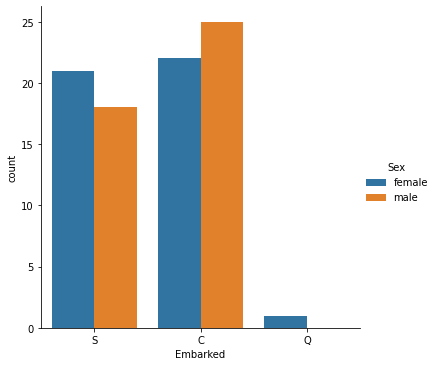

```python
sns.catplot(data=deck_df,x="Embarked",hue='Sex',kind='count')
```

### Now will try to find relation between survival chances of a passenger and the relatives he/she is travelling with on the same deck

In the dataset,the SibSp column refers to the number of siblings travelling and Parch refers to parents.  
If number of SibSp and Parch is equal to zero then the passenger is Alone

```python
def isAlone(human):
    sb=human['SibSp']
    pt=human['Parch']
    return "No" if sb+pt>0 else "Yes"
titanic_df['Alone'] = titanic_df.apply(isAlone,axis=1)
```

```python
titanic_df.head()
```

|  | PassengerId | Survived | Pclass | Name | Sex | Age | SibSp | Parch | Ticket | Fare | Cabin | Embarked | Person | City | Alone |
| --- | --- | --- | --- | --- | --- | --- | --- | --- | --- | --- | --- | --- | --- | --- | --- |
| 0 | 892 | 0 | 3 | Kelly, Mr. James | male | 34.5 | 0 | 0 | 330911 | 7.8292 | NaN | Q | male | Queenstown | Yes |
| 1 | 893 | 1 | 3 | Wilkes, Mrs. James (Ellen Needs) | female | 47.0 | 1 | 0 | 363272 | 7.0000 | NaN | S | female | Southampton | No |
| 2 | 894 | 0 | 2 | Myles, Mr. Thomas Francis | male | 62.0 | 0 | 0 | 240276 | 9.6875 | NaN | Q | male | Queenstown | Yes |
| 3 | 895 | 0 | 3 | Wirz, Mr. Albert | male | 27.0 | 0 | 0 | 315154 | 8.6625 | NaN | S | male | Southampton | Yes |
| 4 | 896 | 1 | 3 | Hirvonen, Mrs. Alexander (Helga E Lindqvist) | female | 22.0 | 1 | 1 | 3101298 | 12.2875 | NaN | S | female | Southampton | No |

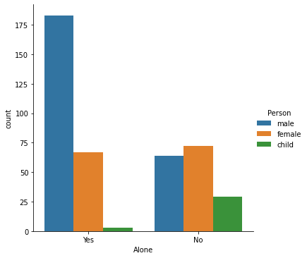

```python
sns.catplot(x='Alone',data=titanic_df,hue='Person',kind='count')
```

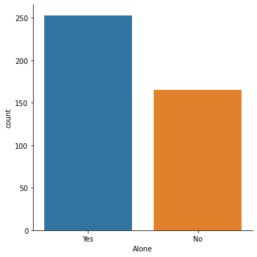

```python
sns.catplot(x='Alone',data=titanic_df,kind='count')
```

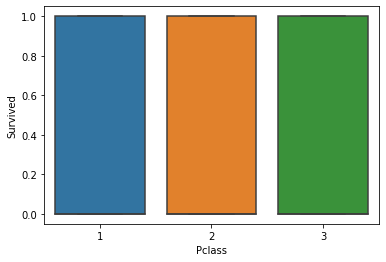

```python
sns.boxplot(x='Pclass',y='Survived',data=titanic_df)
```

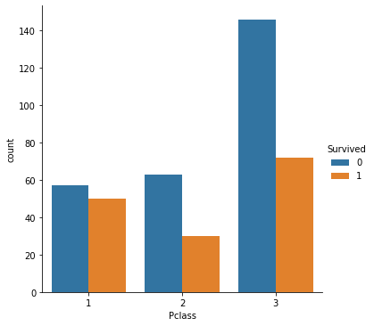

```python
sns.catplot(x='Pclass',data=titanic_df,hue='Survived',kind='count')
```

#### Let's,Find the relation between Survival chances and Pclass

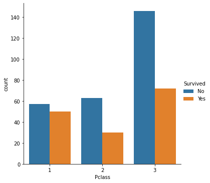

```python
def g_survived(p):
    return "Yes" if p['Survived']==1 else "No"
titanic_df['Survived']=titanic_df.apply(g_survived,axis=1)
sns.catplot(x='Pclass',kind='count',hue='Survived',data=titanic_df)
```

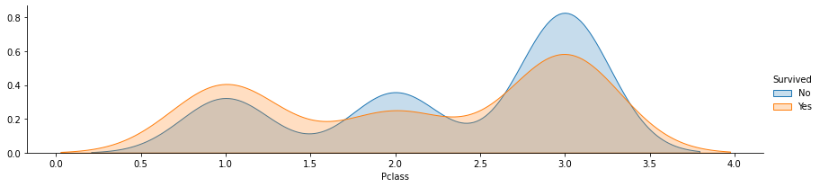

```python
fig = sns.FacetGrid(titanic_df,hue='Survived',aspect=4)
fig.map(sns.kdeplot,'Pclass',shade=True)
fig.add_legend()
```

```python
f_df=titanic_df[(titanic_df.Pclass==1)]
f_df['Pclass'].value_counts()
```

```
1    107
Name: Pclass, dtype: int64
```

```python
s_df=titanic_df[(titanic_df.Pclass==2)]
s_df['Pclass'].value_counts()
```

```
2    93
Name: Pclass, dtype: int64
```

```python
t_df=titanic_df[(titanic_df.Pclass==3)]
t_df['Pclass'].value_counts()
```

```
3    218
Name: Pclass, dtype: int64
```

**In Class 1,Survived vs Person.**

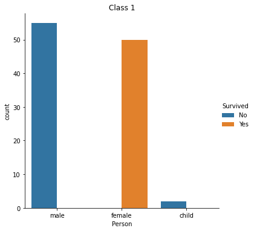

```python
class1=sns.catplot(x='Person',data=f_df,hue='Survived',kind='count')
class1.ax.set_title("Class 1")
```

**In Class 2,Survived vs Person.**

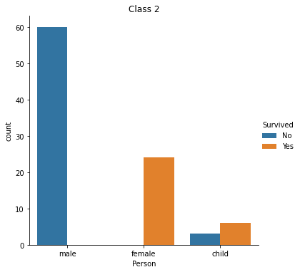

```python
class2=sns.catplot(x='Person',data=s_df,hue='Survived',kind='count')
class2.ax.set_title("Class 2")
```

**In class 3,Survived vs Person.**

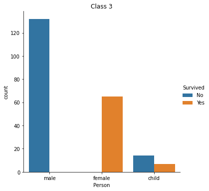

```python
class3=sns.catplot(x='Person',data=t_df,hue='Survived',kind='count')
class3.ax.set_title("Class 3")
```

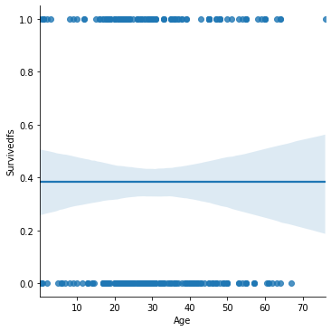

```python
def convst(p):
    return 0 if p['Survived']=='No' else 1
titanic_df['Survivedfs']=titanic_df.apply(convst,axis=1)
sns.lmplot(x='Age',y='Survivedfs',data=titanic_df)
```

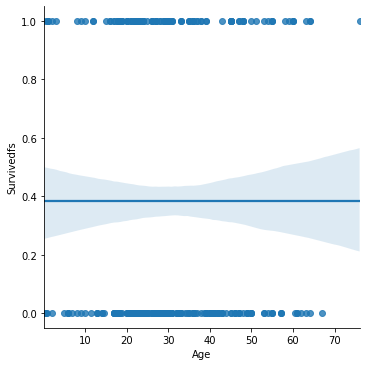

```python
sns.lmplot(x='Age',y='Survivedfs',data=titanic_df)
```

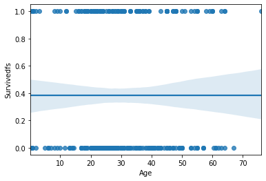

```python
sns.regplot(x='Age',y='Survivedfs',data=titanic_df)
```

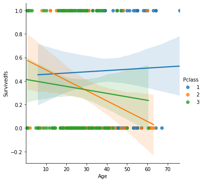

```python
sns.lmplot(x='Age',y='Survivedfs',hue='Pclass',data=titanic_df)
```

### Lets's find whether a person has higher survival chance if he is along with his relatives on deck or he isn't.

[figure not shown]

```python
sns.catplot(x='Alone',hue='Survived',stacked=Truedata=titanic_df,kind='count')
```

```python
titanic_df['Alone'].value_counts()
```

```
Yes    253
No     165
Name: Alone, dtype: int64
```

```python
ns=titanic_df['Survived'].value_counts()
ns
```

```
No     266
Yes    152
Name: Survived, dtype: int64
```

#### Now Let's get into math and find the survival probailities of passengers based on different categories.

```python
total=titanic_df.shape[0]
num_total_sur=titanic_df[titanic_df['Survived']=="Yes"].shape[0]
alone=titanic_df[titanic_df['Alone']=="Yes"]
not_alone=titanic_df[titanic_df['Alone']=="No"]
num_alone=alone.shape[0]
num_not_alone=not_alone.shape[0]
num_alone_sur=alone[alone['Survived']=="Yes"].shape[0]
num_not_alone_sur=not_alone[not_alone['Survived']=="Yes"].shape[0]
f_sur=f_df[f_df['Survived']=='Yes']
num_first=f_df.shape[0]
num_first_sur=f_sur.shape[0]
s_sur=s_df[s_df['Survived']=='Yes']
num_second=s_df.shape[0]
num_second_sur=s_sur.shape[0]
t_sur=t_df[t_df['Survived']=='Yes']
num_third=t_df.shape[0]
num_third_sur=t_sur.shape[0]
male=titanic_df[titanic_df['Person']=='male']
num_male=male.shape[0]
num_male_sur=male[male['Survived']=="Yes"].shape[0]
female=titanic_df[titanic_df['Person']=='female']
num_female=female.shape[0]
num_female_sur=female[female['Survived']=="Yes"].shape[0]
child=titanic_df[titanic_df['Person']=='child']
num_child=child.shape[0]
num_child_sur=child[child['Survived']=="Yes"].shape[0]
S_em=titanic_df[titanic_df['Embarked']=="S"]
num_s=S_em.shape[0]
num_s_sur=S_em[S_em['Survived']=="Yes"].shape[0]
Q_em=titanic_df[titanic_df['Embarked']=="Q"]
num_q=Q_em.shape[0]
num_q_sur=Q_em[Q_em['Survived']=="Yes"].shape[0]
C_em=titanic_df[titanic_df['Embarked']=="C"]
num_c=C_em.shape[0]
num_c_sur=C_em[C_em['Survived']=="Yes"].shape[0]
```

```python
print("------------------Probabilities:------------------------")
print("probability for alone passengers survival::",num_alone_sur/num_alone)
print("probability for family passengers survival::",num_not_alone_sur/num_not_alone)
print("probability for male survival::",num_male_sur/num_male)
print("probability for female survival::",num_female_sur/num_female)
print("probability for children survival::",num_child_sur/num_child)
print("probability for first class passengers survival::",num_first_sur/num_first)
print("probability for second class passengers survival::",num_second_sur/num_second)
print("probability for third class passengers survival::",num_third_sur/num_third)
print("probability for  Southampton passengers survival::",num_s_sur/num_s)
print("probability for  Queenstown passengers survival::",num_q_sur/num_q)
print("probability for  Cherbourg passengers survival::",num_c_sur/num_c)
print()
print()
print("probability for Total passengers survival::",num_total_sur/total)
```

```
------------------Probabilities:------------------------
probability for alone passengers survival:: 0.26877470355731226
probability for family passengers survival:: 0.509090909090909
probability for male survival:: 0.0
probability for female survival:: 1.0
probability for children survival:: 0.40625
probability for first class passengers survival:: 0.4672897196261682
probability for second class passengers survival:: 0.3225806451612903
probability for third class passengers survival:: 0.3302752293577982
probability for  Southampton passengers survival:: 0.32592592592592595
probability for  Queenstown passengers survival:: 0.5217391304347826
probability for  Cherbourg passengers survival:: 0.39215686274509803


probability for Total passengers survival:: 0.36363636363636365
```

All in all , breifly to conclude : Data Analysis domain with python has versatile opportunities which when gone through  
will provide better and valueble insights on the given data. Hope this breif analysis will  
sigh good interest in my future projects

## Many Yet To Discover ..............................................................By Gokula Chandra .K